# Tweet verisi kazıma alıştırmaları

##### **by [Sadettin Demirel](https://twitter.com/demirelsadettin)**

Bu pratikte R progralama dilini kullanarak tweet verilerini çekip analiz edeceğiz.Bunun için cihazınızda R ve Rstudio adlı yazılımları yüklemeniz gereklidir. Kurulumu tamamladıktan sonra paketleri yükleme ve çağırma aşamalarına geçiniz.

##### 1.Paketleri Yükleme ve çağırma

```r
library(tidyverse)
library(rtweet)
library(lubridate)
library(stopwords)
library(tidytext)
```

##### 2.API’ye erişim

API’ye erişim sağlamak için Twitter geliiştirici hesabı ve uygulama oluşturmalısınız.[Detaylar](https://docs.google.com/presentation/d/1DcD-32Aw_XebkoLAuWaGELkdBfrtJY9tLH3BtGmh3lI/edit?usp=sharing) Twitter geliştici hesabını oluşturduktan sonra ve anahtar şifreleri elde ettikten sonra aşağıdaki kodla API’ye erişim sağlıyoruz.

```r
twitter_token <- create_token(app = appname, consumer_key = key,consumer_secret = secret)
```

##### 3. Tweet verisi çekelim

**a. Sağlık Bakanlığı Twitter Hesabı**

Sağlık Bakanlığı’nın paylaştığı son 1000 tweete bakalım

```r
sb <- get_timeline("saglikbakanligi", n=1000)
```

**Etkileşim Analizi**

```r
sb_ozel %>% mutate(date = date(created_at))
```

Öncelikle günlük olarak tweetleri sınıflandıralım.

```r
sb_ozel %>% mutate(date = date(created_at))
```

| created_at | screen_name | text | is_retweet | favorite_count | retweet_count | hashtags | mentions_screen_name | retweet_name | date |
| --- | --- | --- | --- | --- | --- | --- | --- | --- | --- |
| 2019-04-02 05:06:57 | saglikbakanligi | Tüm otizmli kardeşlerime ve ailelerine sevgilerimi iletiyorum. #OtizmFarkındalıkGünü https://t.co/VpXL4wKQGc | TRUE | 0 | 108 |  |  | Dr. Fahrettin Koca | 2019-04-02 |
| 2019-04-01 12:17:26 | saglikbakanligi | Sağlık Bakanlığından ‘Sandık Hizmetleri’ Seferberliği\n\n\U0001f517 https://t.co/3gySxehSve https://t.co/ZDsuZvQZ4T | FALSE | 160 | 31 |  |  | NA | 2019-04-01 |
| 2019-04-01 11:09:10 | saglikbakanligi | Kanserin farkında olun, hayatınızdaki renkler solmasın. \n#KanserHaftası\n#ErkenTeşhisHayatKurtarır https://t.co/WoQ29vgFZI | FALSE | 542 | 338 |  |  | NA | 2019-04-01 |
| 2019-04-01 08:09:06 | saglikbakanligi | Düzenli kontrollerinizi yaptırmayı ihmal etmeyin, sevdiklerinizle birlikte sağlıklı bir yaşam sürün. #KanserHaftası https://t.co/Dy3Ou1k6kx | TRUE | 0 | 152 |  |  | Dr. Fahrettin Koca | 2019-04-01 |
| 2019-03-31 14:38:27 | saglikbakanligi | 31 Mart Mahalli İdareler Genel Seçimlerinde, Evde Sağlık Hizmeti alan vatandaşlarımız ambulans ve evde sağlık araçlarıyla taşındı. https://t.co/DSvYZ7qrvn | TRUE | 0 | 3 |  |  | K.Maraş İl Sağlık | 2019-03-31 |
| 2019-03-31 14:19:25 | saglikbakanligi | 31 Mart Yerel Seçimlerinde, Evde Sağlık Hizmetleri birimimiz ve Acil 112 Ekiplerimizce demokratik haklarını kullanmak isteyen yaşlı, engelli ve hastanede yatan vatandaşlarımızı seçim sandıklarına güve… | TRUE | 0 | 6 |  |  | Burdur İl Sağlık Müd | 2019-03-31 |
| 2019-03-31 14:00:37 | saglikbakanligi | 31 Mart Yerel Seçimlerinde sağlık sorunları nedeniyle sandık başına gidemeyen vatandaşın oy kullanabilmeleri için 112 sağlık ekiplerimiz görev başında\n@saglikbakanligi https://t.co/NqHvM4r9Hy | TRUE | 0 | 5 |  |  | Malatya İl Sağlık Md. | 2019-03-31 |
| 2019-03-31 14:00:01 | saglikbakanligi | 31 Mart Mahalli İdareler Genel Seçimlerinde, Evde Sağlık Hizmeti alan vatandaşlarımız ambulans ve evde sağlık araçlarıyla sabah saatlerinden başlayarak, seçmenleri 16:00'a kadar oy kullanacakları sand… | TRUE | 0 | 6 |  |  | Adıyaman İl Sağ.Müd. | 2019-03-31 |
| 2019-03-31 13:42:43 | saglikbakanligi | 2019 yerel seçimlerinde, vatandaşlarımızın gerektiğinde acil müdahale edebilecek tam teşekküllü ambulanslar, hasta nakil araçları ve deneyimli sağlık ekipleri eşliğinde sandığa gidebilmesi sağlanıyor.… | TRUE | 0 | 4 |  |  | İstanbul Sağlık Müd. | 2019-03-31 |
| 2019-03-31 13:42:30 | saglikbakanligi | Hastalarımızın Vatandaşlık haklarını yerine getirebilmeleri için engellerini kaldırmak üzere yanlarındayız. @sbkhgm @saglikbakanligi https://t.co/Hwd4YRDcQZ | TRUE | 0 | 4 |  |  | Amasya İl Sağlık Müd | 2019-03-31 |

[output cut: 990 more lines]

Tabloda retweet ve beğenilme sayılarına bakalım

```r
sb_ozel %>% select(screen_name, favorite_count, retweet_count)%>% arrange(desc(favorite_count,retweet_count))
```

```r
sb_ozel %>% select(screen_name, favorite_count, retweet_count)%>% arrange(desc(favorite_count,retweet_count))
```

| screen_name | favorite_count | retweet_count |
| --- | --- | --- |
| saglikbakanligi | 33816 | 7321 |
| saglikbakanligi | 6023 | 1767 |
| saglikbakanligi | 3992 | 788 |
| saglikbakanligi | 3434 | 777 |
| saglikbakanligi | 1967 | 745 |
| saglikbakanligi | 1497 | 151 |
| saglikbakanligi | 1302 | 119 |
| saglikbakanligi | 1199 | 478 |
| saglikbakanligi | 1158 | 510 |
| saglikbakanligi | 1098 | 409 |

[output cut: 990 more lines]

Görselleştirelim

```r
sb_ozel %>% mutate(date = date(created_at)) %>% ggplot(aes(date, retweet_count))+geom_line()
```

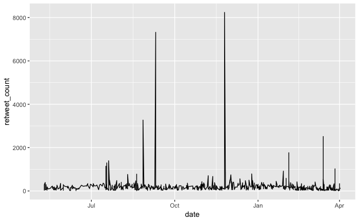

```r
sb_ozel %>% mutate(date = date(created_at)) %>% ggplot(aes(date, retweet_count))+geom_line()
```

**Kullanılan Etiket analizi**

Etiket analiz biraz meşakkatli. Kullanıcılar birden fazla etiket kullandığı için Twitter bize veriyi liste olarak sunuyor. Doğal olarak bunu tablo formatına çevirmemiz için aşağıdaki kodu kullanacağız.

```r
# bir nevi veriyi istediğimiz formata getirmek için bir hack kodda diyebiliriz buna
sb_etiket <- data.frame(matrix(unlist(sb_ozel$hashtags), nrow = 1051, byrow = TRUE),stringsAsFactors = FALSE)

#sütun ismini değiştiriyoruz
colnames(sb_etiket) <- c("etiket")

#en çok hangi etiketler kullanılmış.
sb_etiket %>% count(etiket, sort = TRUE)
```

| etiket | n |
| --- | --- |
| NA | 696 |
| HerGün10BinAdım | 20 |
| 14MartTıpBayramı | 17 |
| SağlıklıBayram | 15 |
| AileHekiminiziErkenTanıyın | 14 |
| KurbanBayramı | 10 |
| RamazandaSağlığım | 10 |
| VeremEğitimiVeFarkındalıkHaftası | 9 |
| DünyaEmojiGünü | 8 |
| ErkenTeşhisHayatKurtarır | 8 |

[output cut: 148 more lines]

**Retweet analizi**

Sağlık Bakanlığı en çok **Dr.Fahrettin Koca’yı** retweet etmiş

```r
sb_ozel %>% count(retweet_name, sort = TRUE)
```

| retweet_name | n |
| --- | --- |
| NA | 481 |
| Dr. Fahrettin Koca | 446 |
| Sağlıklı Yaşa | 30 |
| T.C. Cumhurbaşkanlığı | 14 |
| Dr Ahmet Demircan | 4 |
| AA Canlı | 2 |
| ANADOLU AJANSI | 2 |
| Emine Erdoğan | 2 |
| Sağlık Çocuk | 2 |
| AB ve Dış İlişkiler | 1 |

[output cut: 16 more lines]

**Metin analizi**

Metin verisini seçelim

```r
sb_metin <- sb_ozel %>% select(text)
```

```r
tweet_kelime <- sb_metin %>%
  filter(!str_detect(text, '^"')) %>%
  mutate(text = str_replace_all(text, "https://t.co/[A-Za-z\\d]+|&amp;", "")) %>%
  unnest_tokens(word, text, token = "tweets", to_lower = TRUE) %>%
  filter(!word %in% stopwords::stopwords("tr", source = "stopwords-iso"),
         str_detect(word, "[a-z]"))
```

```r
tweet_kelime %>% count(word, sort = TRUE)
```

```r
tweet_kelime %>% count(word, sort = TRUE)
```

| word | n |
| --- | --- |
| sağlık | 369 |
| sayın | 145 |
| dr | 89 |
| şehir | 72 |
| sağlıklı | 70 |
| hakkında | 62 |
| ziyaret | 62 |
| bilgi | 52 |
| bulunduk | 47 |
| bakanımız | 46 |

[output cut: 990 more lines]

**b. #Seçim2019 Etiket Analizi**

En çok tweet atan hesap hangisi

```r
secim <- search_tweets("#seçim2019", n = 10000)
secim %>% count(screen_name, sort = TRUE)
```

| screen_name | n |
| --- | --- |
| halktvcomtr | 44 |
| _gullerevurgun3 | 26 |
| gazeteyolculuk | 25 |
| Rojname_com | 21 |
| anarchimedeann | 18 |
| rte_202301 | 18 |
| yeniakit | 16 |
| beytullah_ekber | 15 |
| RabiaBirlik131 | 15 |
| Newsfrom_Gr_Tr | 13 |

[output cut: 990 more lines]

**Diğer kullanılan Etiketler**

Başka hangi etiketler kullanılıyor.

```r
# bir nevi veriyi istediğimiz formata getirmek için bir hack kodda diyebiliriz buna
secim_etiket <- data.frame(matrix(unlist(secim$hashtags), nrow = 13670, byrow = TRUE),stringsAsFactors = FALSE)

#sütun ismini değiştiriyoruz
colnames(secim_etiket) <- c("etiket")

#en çok hangi etiketler kullanılmış.
secim_etiket %>% count(etiket, sort = TRUE) %>% na.omit()
```

| etiket | n |
| --- | --- |
| Seçim2019 | 2950 |
| Secim2019 | 938 |
| MartınSonuBaharOldu | 693 |
| HırsızVar | 588 |
| seçim2019 | 494 |
| Ekremİmamoğlu | 323 |
| CHP | 293 |
| Sancaktepe | 192 |
| baharınilkgünü | 174 |
| hırsızvar | 167 |

[output cut: 990 more lines]

**Ayrıca en çok kullanılan kelimelere bakalım**

```r
secim_tweet <- select(secim,text) %>%
  filter(!str_detect(text, '^"')) %>%
  mutate(text = str_replace_all(text, "https://t.co/[A-Za-z\\d]+|&amp;", "")) %>%
  unnest_tokens(word, text, token = "tweets", to_lower = TRUE) %>%
  filter(!word %in% stopwords::stopwords("tr", source = "stopwords-iso"),
         str_detect(word, "[a-z]"))
```

```r
secim_tweet %>% count(word, sort = TRUE)
```

| word | n |
| --- | --- |
| #seçim2019 | 5704 |
| #secim2019 | 1390 |
| seçim | 1124 |
| #martınsonubaharoldu | 973 |
| #hırsızvar | 930 |
| oy | 817 |
| i̇stanbul | 578 |
| belediye | 553 |
| #ekremi̇mamoğlu | 509 |
| i̇lçe | 462 |

[output cut: 990 more lines]

##### 4. Faydalı kaynaklar

- [Rtweet paketi kodları](https://rtweet.info/index.html)
- [R üzerine yazılarım](https://www.newslabturkey.org/author/sadettindemirel/)
- [Tweet verisi üzerine detaylı yazım](https://www.newslabturkey.org/r-ile-tweet-verisi-nasil-cekilir-ve-analiz-edilir/)
- [İstanbul ve Ankara adayları analizim](https://twitter.com/demirelsadettin/status/1112058333266169856)
- [Üstteki analizin kodları](https://sadettindemirel.github.io/mayoral_candidates_tweets/analysis-of-tweets.html)
- [Veri Okuryazarlığı Derneği (VOYD)](https://www.voyd.org.tr)
- [Dernek olarak her hafta yayınladığımız Veri Bülteni](https://twitter.com/voydorg/status/1083695779141861376)